# Ukraine Twitter Sentiment Analysis

Gabriel Valverde Zanata da Silva

2023-01-18

## Objetivo - Análise de Sentimentos

Este projeto tem como objetivo capturar dados mais recentes da rede social Twitter e realizar uma análise de sentimentos dos usuários em relação ao conflito na Ucrânia. Por meio deste, será possível identificar as palavras em alta, a tendência geral de sentimento (positivo/neagativo) e também as emoções e palavras carregadas de sentimento mais utilizadas no momento. Dessa forma é possível inferir a temperatura do conflito e dos acontecimentos recentes, bem como identificar acontecimentos relevantes.

## Etapa 1 - Pacotes e Bibliotecas Necessárias

```r
# Pacotes essenciais
library(plyr)
library(dplyr)
library(ggplot2)
library(lattice)
library(knitr)
library(rmarkdown)

# Autenticação e manipulação Twitter
library(rtweet)
library(httr)

# Text mining
library(SnowballC)
library(tm)

# Visualização Nuvem de Palavras
library(wordcloud)
library(RColorBrewer)

# Manipulação de texto
library(stringr)

# Classificação de emoções
library(syuzhet)
library(textdata)
library(tidytext)
```

## Etapa 2 - Autenticação e Conexão ao Twitter

Para realizar a extração de dados (Tweets) do Twitter é necessário criar e ter acesso uma aplicação. Para isso é preciso possuir uma conta de usuário no Twitter e solicitar, por meio desta conta, o acesso de desenvolvedor. Após criada a aplicação é imprescindível solicitar o “Elevated Access” para se obter permissão de conexão e extração de dados via linguagem R. Estas solicitações, até a data deste projeto, são gratuitas e de fácil obtenção. Ainda na aplicação, é necessário alterar as permissões de acesso para “Read and Write”, além de anotar cada uma das chaves (Keys) fornecidas até então. Prosseguindo para o código realiza-se a conexão entre o RStudio e a aplicação por meio da chave “bearer_key” conforme abaixo:

```r
bearer_token <- "****************************"
```

```r
my_app <- rtweet_app(bearer_token)
auth_as(my_app)
```

Outros métodos do pacote rtweet para a conexão com o Twitter podem ser utilizados, conforme a necessidade.

## Etapa 3 - Obtenção e Tratamento de Dados

A extração de dados (tweets) pode ser facilmente realizada através da função search_tweets, onde é possível selecionar o tema alvo, a quantidade de tweets (que é limitada conforme o nível de acesso da aplicação, neste caso: “Elevated Access”), além de outros parâmetros que podem ser estudados mais a fundo através da documentação.

```r
tweetdata <- search_tweets("#Ukraine", # tema
                           n = 500, # selecionando 500 tweets
                           include_rts = F, # excluindo RTs
                           type = "recent", # tweets mais recentes
                           parse = T, # organizando em dataframe
                           lang = "en" ) # apenas tweets em inglês

head(tweetdata) # Visualizando o formato dos dados
```

```
## # A tibble: 6 × 43
##   created_at               id id_str   text  full_…¹ trunc…² entities     source
##   <dttm>                <dbl> <chr>    <chr> <chr>   <lgl>   <list>       <chr>
## 1 2023-01-18 13:43:16 1.62e18 1615751… "@Bu… "@Bund… FALSE   <named list> "<a h…
## 2 2023-01-18 13:43:11 1.62e18 1615751… "#Uk… "#Ukra… FALSE   <named list> "<a h…
## 3 2023-01-18 13:43:10 1.62e18 1615751… "\"T… "\"Thi… FALSE   <named list> "<a h…
## 4 2023-01-18 13:43:00 1.62e18 1615751… "#Uk… "#Ukra… FALSE   <named list> "<a h…
## 5 2023-01-18 13:42:47 1.62e18 1615751… "Foo… "Foota… FALSE   <named list> "<a h…
## 6 2023-01-18 13:42:41 1.62e18 1615751… "Onc… "Once … FALSE   <named list> "<a h…
## # … with 35 more variables: in_reply_to_status_id <dbl>,
## #   in_reply_to_status_id_str <chr>, in_reply_to_user_id <dbl>,
## #   in_reply_to_user_id_str <chr>, in_reply_to_screen_name <chr>, geo <list>,
## #   coordinates <list>, place <list>, contributors <lgl>,
## #   is_quote_status <lgl>, retweet_count <int>, favorite_count <int>,
## #   favorited <lgl>, favorited_by <lgl>, retweeted <lgl>, scopes <lgl>,
## #   lang <chr>, possibly_sensitive <lgl>, display_text_width <lgl>, …
```

Uma vez obtidos os tweets desejados, todo o trabalho restante pode ser feito offline no RStudio. É necessário tratar os dados para adequá-los às funções que serão utilizadas e aos objetivos do projeto. Por se tratar de um objeto texto, é possível manipulá-lo de maneira precisa através de funções regulares, removendo elementos do texto que prejudicariam a análise ou sejam irrelevantes.

```r
# Tratando os Dados com Expressões Regulares
tweetList <- tweetdata$text # Obtendo o texto dos tweets

# Removendo caracteres especiais
tweetList = gsub("(RT|via)((?:\\b\\W*@\\w+)+)", "", tweetList)

# Removendo @
tweetList = gsub("@\\w+", "", tweetList)

# Removendo pontuação
tweetList = gsub("[[:punct:]]", "", tweetList)

# Removendo digitos
tweetList = gsub("[[:digit:]]", "", tweetList)

# Removendo links html
tweetList = gsub("http\\w+", "", tweetList)

# Removendo espacos desnecessários
tweetList = gsub("[ \t]{2,}", "", tweetList)
tweetList = gsub("^\\s+|\\s+$", "", tweetList)
tweetList = gsub("[\n]{2,}", " ", tweetList)
```

## Etapa 4 - Análise de Sentimentos

De posse dos dados limpos, é possível análisar a incidência de palavras mais frequentes por meio de uma nuvem de palavras.

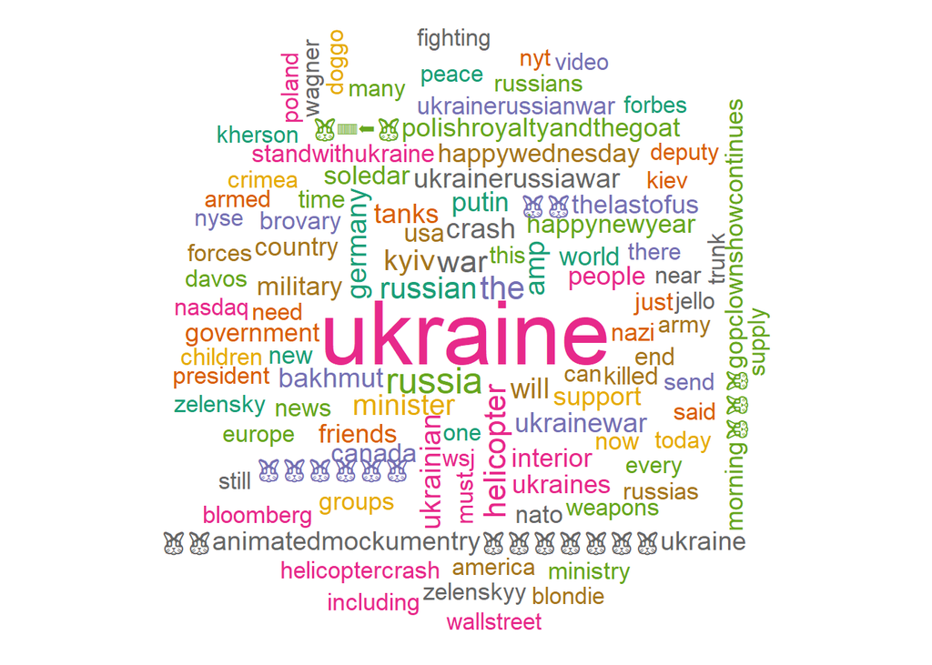

```r
pal <- brewer.pal(8, "Dark2") #Criando paleta de cores

wordcloud(tweetList,
          scale = c(4,1),
          min.freq = 4,
          random.color = T,
          random.order = F,
          max.words = 100,
          colors = pal)
```

Para a análise de sentimentos, ainda são necessárias algumas alterações e manipulações. A função sentiment.scores transforma todos os caracteres em letras minúsculas e realiza uma contagem de palavras correspondentes entre o dataset fornecido e uma lista de palavras classificadas como positivas ou negativas, atribuindo pontuação positiva e negativa conforme a correspondência. O resultado é um dataframe com a pontuação de cada sentença.

```r
sentiment.score = function(sentences, pos.words, neg.words, .progress = 'none')
{
  # Criando um array de scores
  scores = laply(sentences,
                 function(sentence, pos.words, neg.words)
                 {
                   sentence = gsub("[[:punct:]]", "", sentence)
                   sentence = gsub("[[:cntrl:]]", "", sentence)
                   sentence = gsub('\\d+', '', sentence)
                   tryTolower = function(x)
                   {
                     y = NA
                     try_error = tryCatch(tolower(x), error=function(e) e)
                     if (!inherits(try_error, "error"))
                       y = tolower(x)
                     return(y)
                   }
                   sentence = sapply(sentence, tryTolower)
                   word.list = str_split(sentence, "\\s+")
                   words = unlist(word.list)
                   pos.matches = match(words, pos.words)
                   neg.matches = match(words, neg.words)
                   pos.matches = !is.na(pos.matches)
                   neg.matches = !is.na(neg.matches)
                   score = sum(pos.matches) - sum(neg.matches)
                   return(score)
                 }, pos.words, neg.words, .progress = .progress )
  scores.df = data.frame(text = sentences, score = scores)
  return(scores.df)
}
```

As listas de palavras positivas e negativas foram fornecidas ao código por meio de documentos de texto, que devem estar dentro do diretório de trabalho do projeto.

```r
pos = readLines("palavras_positivas.txt")
neg = readLines("palavras_negativas.txt")

# Aplicando a função sentiment score nos tweets extraídos
scores = sentiment.score(tweetList, pos, neg, .progress = 'none')
```

Manipulando e organizando os resultados para plotagem do gráficos de barras, para visualização da distribuição geral dos scores.

```r
scores$pos = as.numeric(scores$score >= 1)
scores$neg = as.numeric(scores$score >= -1)

numpos = sum(scores$pos)
numneg = sum(scores$neg)
global_score = round( 100 * numpos / (numpos + numneg) )
head(scores)
```

```
##                                                                                                                                                                                                                                                            text
## 1                                                                                                        There are no political and peaceful strategies for this bloodthirsty people to end this disastrous war WarCrimes \nBrovary UkraineWest\nPresidentItaly
## 2                                                                                                                                                                               Ukraine They want to have democracy amp we are democratic countries per Polands
## 3                                                                  This assistance we have sent to Ukraine is still not enoughwe should mobilize ourselves to help them per Polands Next crucial moments of this war coming in maybe months maybe weeks he says
## 4                                                                                                                                                                                                                                 Ukraine Please read amp share
## 5 Footage of a fire appeared after a helicopter fell from a height in Brovarya terrifying scale of the spread of fire is visible  UkraineRussianWar UkraineKherson Soledar Wagner ATACMS Bakhmut Kramatorsk Luhansk Ukraina Zaporizhzhia Crimea Соледар Soledar
## 6                                                                                                                                         Once vibrant city of Marinka looks like this today Russians attacking the town sinceMarch  UkraineRussiaWar \nUkraine
##   score pos neg
## 1    -1   0   1
## 2     0   0   1
## 3     0   0   1
## 4     0   0   1
## 5    -1   0   1
## 6     2   1   1
```

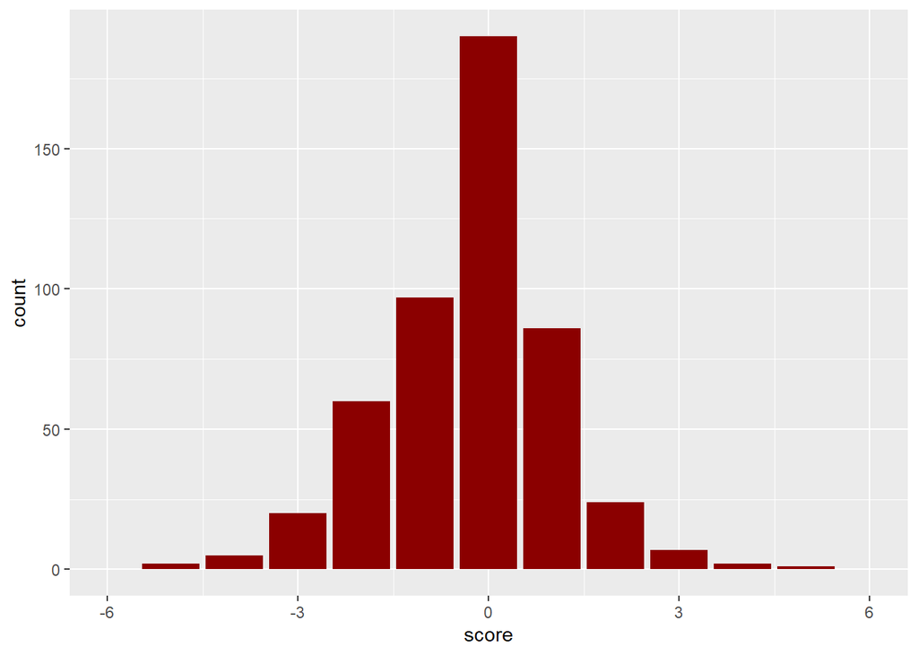

```r
# Gerando gráfico de colunas para os sentimentos positivos/negativos
color <- ifelse(global_score >= 50,"darkgreen","darkred")
p <- ggplot(data = scores) + geom_bar(mapping = aes(x = score), fill = color)
p + xlim(-6,6)
```

## Etapa 5 - Classificação de Emoções

Para uma análise mais profunda dos sentimentos é possível analisá-los em termos de emoção e não apenas “positivo / negativo”. Para utilizar as funções de classificação de emoção realiza-se uma manipulação breve dos dados, tornando as letras em minúsculas e removendo valores NA.

```r
# Criando função para tolower
try.error = function(x)
{
  # Criando missing value
  y = NA
  try_error = tryCatch(tolower(x), error=function(e) e)
  if (!inherits(try_error, "error"))
    y = tolower(x)
  return(y)
}

# Lower case
tweetList = sapply(tweetList, try.error)
# Removendo os NAs
tweetList = tweetList [!is.na(tweetList)]
names(tweetList) = NULL
```

O pacote syuzhet pode ser aplicado para classficar a quantidade de palavras, em cada sentença, que corresponda a uma das 8 emoções presentes no pacote.

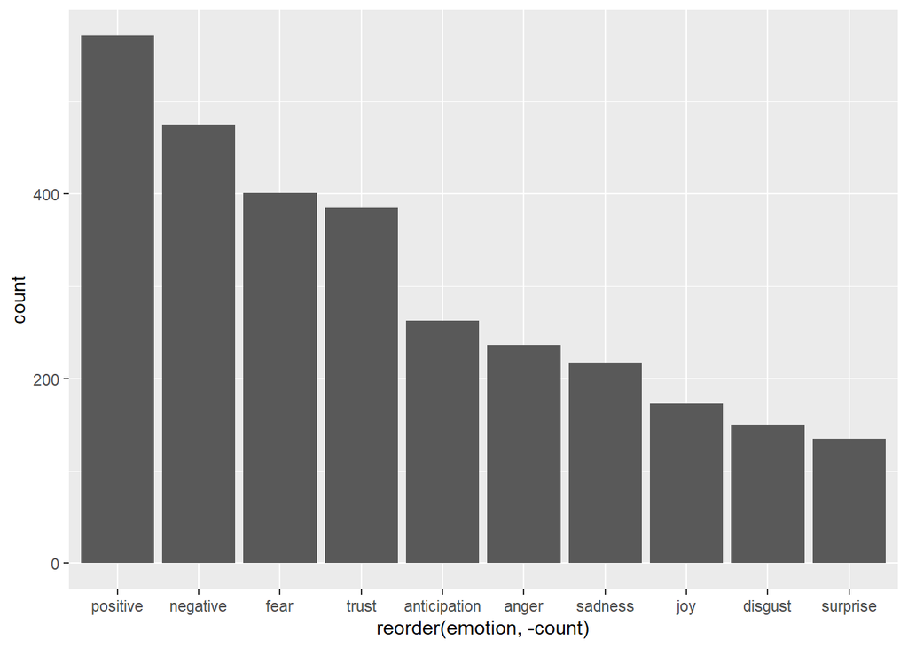

```r
# Classifcando emoções com syuzhet
emotions <- get_nrc_sentiment(tweetList)
emo_bar <- colSums(emotions)
emo_sum <- data.frame(count = emo_bar, emotion = names(emo_bar))

# Barplot com a contagem de emoções
ggplot(emo_sum, aes(x = reorder(emotion, -count), y = count)) +
  geom_bar (stat = "identity")
```

O pacote tidytext pode ser utilizado para classificação de emoções conforme o dicionários do pacote. Para este projeto foram utilizados os dicionários “Bing” e “Loughran” que classficam as palvras, respectivamente, em positivo / negativo e 6 emoções diferentes. Após a classficação, foi realizado um Top10 das palavras mais relevantes em cada classficação.

```r
# Classifcando emoções com o Dicionário Bing
df <- as.data.frame(tweetList)

bing <- df %>% unnest_tokens(word, tweetList) %>%
  inner_join(get_sentiments("bing")) %>%
  count(word, sentiment, sort = TRUE)

# Selecionando Top 10 positivas e negativas
bing_top10 <-  bing %>%
  group_by(sentiment) %>%
  slice_max(order_by = n, n = 10) %>%
  ungroup() %>%
  mutate(word = reorder(word, n))
bing_top10
```

```
## # A tibble: 25 × 3
##    word      sentiment     n
##    <fct>     <chr>     <int>
##  1 crash     negative     45
##  2 tanks     negative     33
##  3 killed    negative     22
##  4 died      negative     11
##  5 crashed   negative      9
##  6 death     negative      7
##  7 blame     negative      6
##  8 breaking  negative      6
##  9 offensive negative      6
## 10 tank      negative      6
## # … with 15 more rows
```

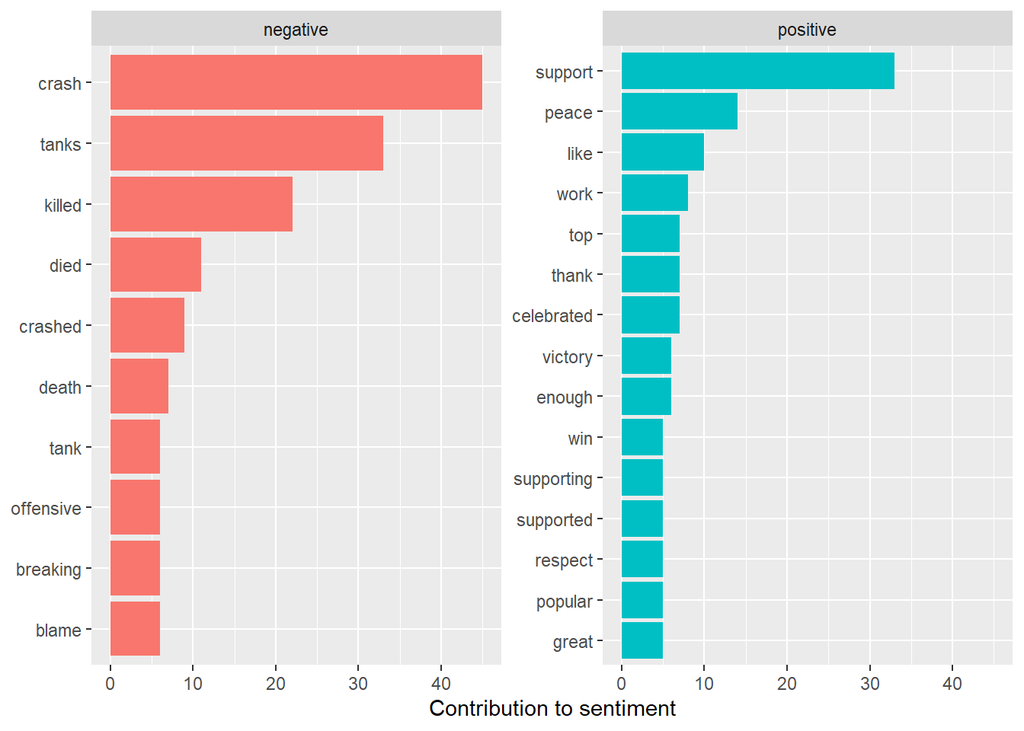

```r
# Plotando
bing_top10 %>% ggplot(aes(word, n, fill = sentiment)) +
  geom_col(show.legend = F) +
  facet_wrap(~sentiment, scales = "free_y") +
  labs (y = "Contribution to sentiment", x = NULL) +
  coord_flip()
```

```r
# Classifcando emoções com o dicionário Loughran

loughran <- df %>% unnest_tokens(word, tweetList) %>%
  inner_join(get_sentiments("loughran")) %>%
  count(word, sentiment, sort = TRUE)

# Selecionando Top 10 positivas e negativas
loughran_top10 <-  loughran %>%
  group_by(sentiment) %>%
  slice_max(order_by = n, n = 10, with_ties = F) %>%
  ungroup() %>%
  mutate(word = reorder(word, n))
loughran_top10
```

```
## # A tibble: 48 × 3
##    word         sentiment        n
##    <fct>        <chr>        <int>
##  1 committed    constraining     3
##  2 committing   constraining     2
##  3 depends      constraining     1
##  4 earmarked    constraining     1
##  5 limit        constraining     1
##  6 prevent      constraining     1
##  7 prevented    constraining     1
##  8 requirements constraining     1
##  9 claims       litigious        5
## 10 amendment    litigious        2
## # … with 38 more rows
```

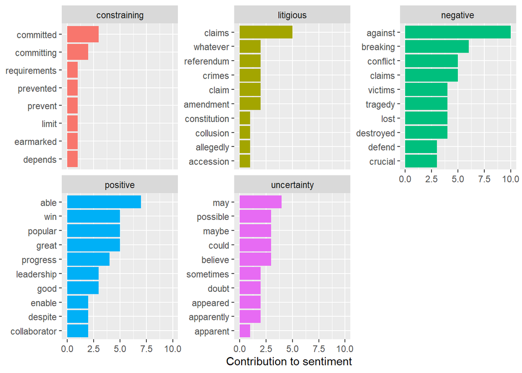

```r
# Plotando
loughran_top10 %>% ggplot(aes(word, n, fill = sentiment)) +
  geom_col(show.legend = F) +
  facet_wrap(~sentiment, scales = "free_y") +
  labs (y = "Contribution to sentiment", x = NULL) +
  coord_flip()
```

## Etapa 6 - Análise dos resultados

De posse do código descrito anteriormente, como dito no início, é possível utilizar os outputs para análise do tema alvo, identificando o sentimento geral das pessoas, suas emoções e até mesmo incidentes notáveis, possívelmente relacionando todos estes pontos. Vale notar que não há necessidade de realizar uma análise aprofundada dos dadso neste documento, uma vez que os dados e tendências são análisados quase em tempo real, e a dinamicidade de assuntos no Twitter é muito alta.

### Incidentes e Assuntos Notáveis

Na nuvem de palavras pode-se identifcar as palavras mais frequentes nos 500 tweets mais recentes sobre o conflito na Ucrânia.

[figure not shown]

Em uma nuvem de palavras, quanto maior o tamanho da palavra, maior sua frequência em relação às demais. Dessa forma é possível retirar insights interessantes da imagem, como o tema alvo “Ukraine” (Ucrânia), e partes relevantes envolvidas direta ou indiretamente no conflito, como Russia, Alemanha, EUA, OTAN, Canada, Putin, etc.

### Sentimento Geral

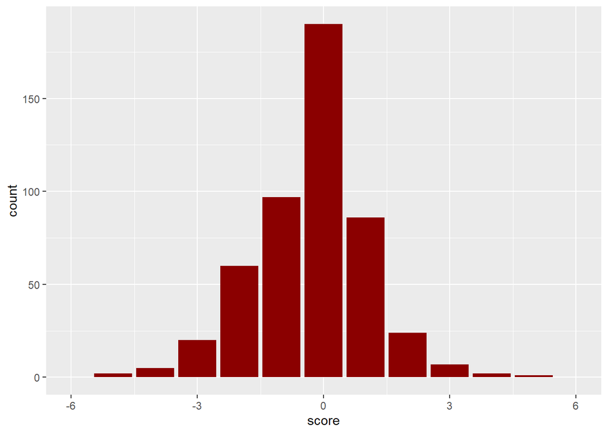

### Emoções

Em relação às emoções, é possível analisar a incidência das emoções mais comuns em ordem decrescente, e analisar a emoção geral do público em dado instante.

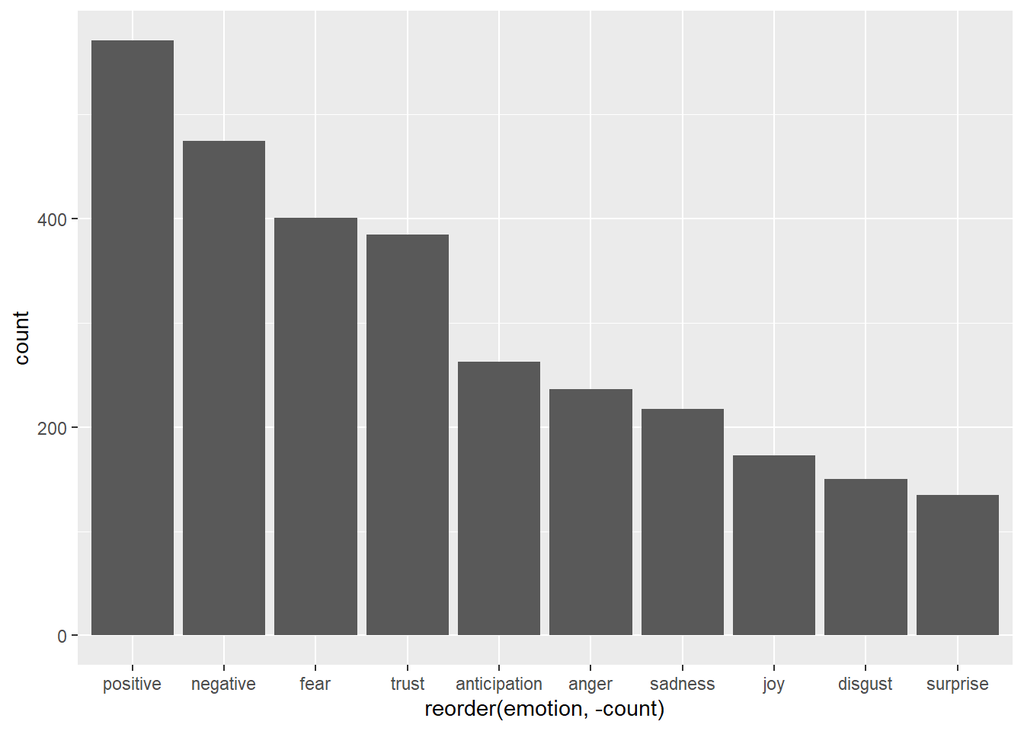

Nos dois plots abaixo é possível analisar as palavras mais frequentes de cada teor emocional de maneira individual, de modo a indentificar os assuntos mais relevantes do momento e sua carga emocional.

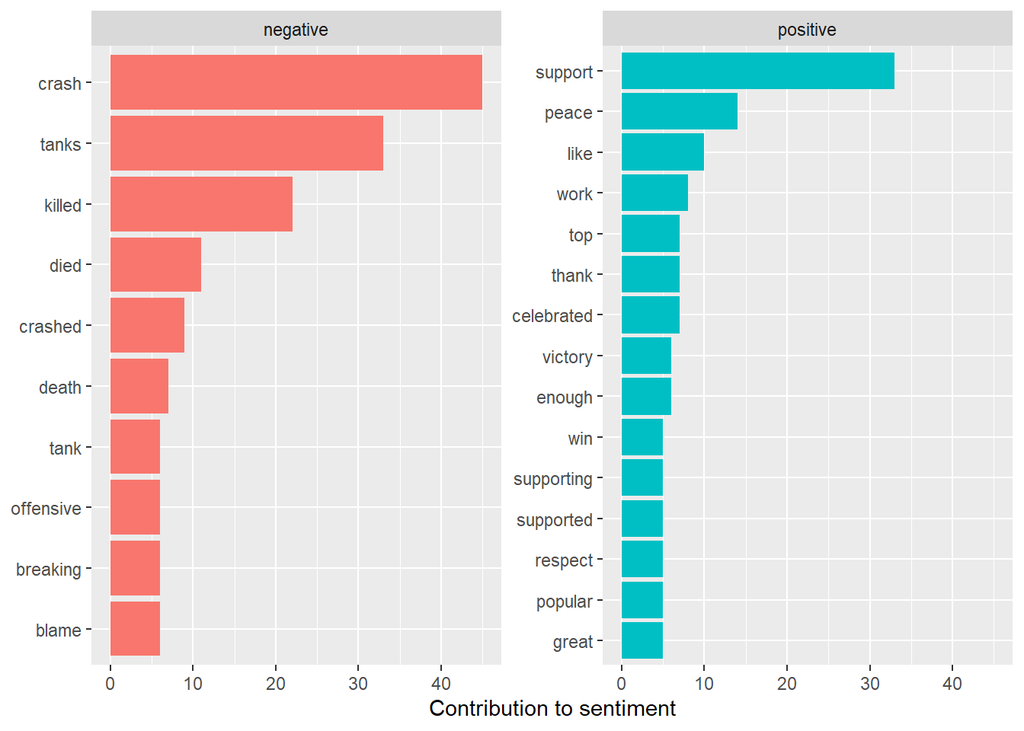

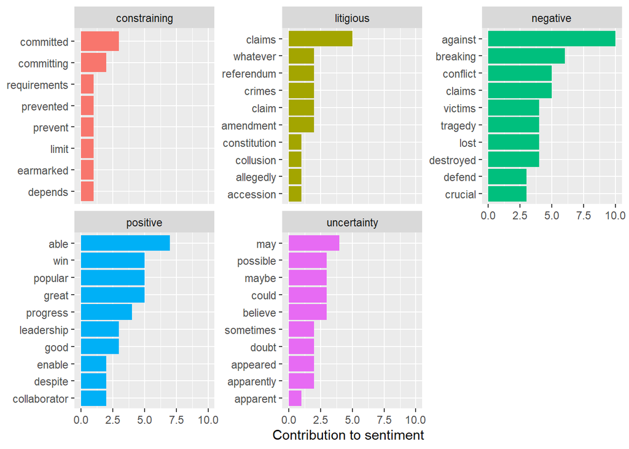